# **CIND-119 - Final group project - Credit Card Dataset**

# Aim of the Project

The aim of this project is to develop a reliable data analytics strategy to assist a bank in making informed loan approval decisions. By leveraging machine learning techniques, specifically Decision Tree and Naive Bayes classifiers, the project aims to predict the credit risk of potential customers based on historical data. This predictive modeling will help the bank minimize the risk of default by accurately identifying customers with good and bad credit risks. Another words, this dataset addresses the challenge of a bank in deciding on loan approval to customers. A bank needs to make the right decision in determining who should get the approval and who should not.

# Summary of Dataset

The dataset used in this project is the German Credit Data dataset, which consists of 1000 entries and 21 attributes. The attributes include various financial and personal characteristics of customers, such as account balance, credit amount, duration of credit, payment status of previous credit, purpose of the loan, and more. The class attribute, 'Creditability', is a binary variable indicating whether the customer's credit rating is good (1) or bad (0). The dataset provides a comprehensive set of features that can be utilized to build effective predictive models for credit risk assessment.

# Tools and Machine Learning Methods in Python:

To achieve the aim of this project, the following tools and machine learning methods were employed using Python:

These tools and methods collectively enable the development, training, evaluation, and visualization of the predictive models, thereby facilitating a comprehensive analysis of the credit risk prediction problem.

# Part (A) of the project

## Upload the dataset

```python
from google.colab import files
uploaded = files.upload()
```

Upload widget is only available when the cell has been executed in the current browser session. Please rerun this cell to enable.

```
Saving german_credit.arff to german_credit.arff
```

```python
import matplotlib.pyplot as plt
import seaborn as sns
```

```python
import pandas as pd
from scipy.io import arff
import numpy as np

data_file="german_credit.arff"
data = arff.loadarff(data_file)

df=pd.DataFrame(data[0])
for col in df.columns:
  if df[col].dtype=='object':
    #making sure data is not read as bytes but as string values from a file
    df[col] = df[col].str.decode('utf-8')
```

## Look at the attribute type. e.g., nominal, ordinal or quantitative.

```python
print(df.dtypes)
```

```
Creditability                         object
Account Balance                       object
Duration of Credit (month)           float64
Payment Status of Previous Credit     object
Purpose                               object
Credit Amount                        float64
Value Savings/Stocks                  object
Length of current employment          object
Instalment per cent                  float64
Sex & Marital Status                  object
Guarantors                            object
Duration in Current address           object
Most valuable available asset         object
Age (years)                          float64
Concurrent Credits                    object
Type of apartment                     object
No of Credits at this Bank           float64
Occupation                            object
No of dependents                     float64
Telephone                             object
Foreign Worker                        object
dtype: object
```

```python
import pandas as pd
data = {"FeatureName": df.columns.tolist(),
    "Type": ["Nominal", "Ordinal", "Quantitative", "Ordinal", "Nominal","Quantitative", "Ordinal", "Ordinal", "Quantitative", "Nominal",
        "Nominal", "Ordinal", "Nominal", "Quantitative", "Nominal",  "Nominal", "Quantitative", "Nominal", "Quantitative", "Nominal", "Nominal"]
}
df_type = pd.DataFrame(data)
print(df_type)
```

```
                          FeatureName          Type
0                       Creditability       Nominal
1                     Account Balance       Ordinal
2          Duration of Credit (month)  Quantitative
3   Payment Status of Previous Credit       Ordinal
4                             Purpose       Nominal
5                       Credit Amount  Quantitative
6                Value Savings/Stocks       Ordinal
7        Length of current employment       Ordinal
8                 Instalment per cent  Quantitative
9                Sex & Marital Status       Nominal
10                         Guarantors       Nominal
11        Duration in Current address       Ordinal
12      Most valuable available asset       Nominal
13                        Age (years)  Quantitative
14                 Concurrent Credits       Nominal
15                  Type of apartment       Nominal
16         No of Credits at this Bank  Quantitative
17                         Occupation       Nominal
18                   No of dependents  Quantitative
19                          Telephone       Nominal
20                     Foreign Worker       Nominal
```

```python
df.head(5)
```

|  | Creditability | Account Balance | Duration of Credit (month) | Payment Status of Previous Credit | Purpose | Credit Amount | Value Savings/Stocks | Length of current employment | Instalment per cent | Sex & Marital Status | ... | Duration in Current address | Most valuable available asset | Age (years) | Concurrent Credits | Type of apartment | No of Credits at this Bank | Occupation | No of dependents | Telephone | Foreign Worker |
| --- | --- | --- | --- | --- | --- | --- | --- | --- | --- | --- | --- | --- | --- | --- | --- | --- | --- | --- | --- | --- | --- |
| 0 | 1 | 1 | 18.0 | 4 | 2 | 1049.0 | 1 | 2 | 4.0 | 2 | ... | 4 | 2 | 21.0 | 3 | 1 | 1.0 | 3 | 1.0 | 1 | 1 |
| 1 | 1 | 1 | 9.0 | 4 | 0 | 2799.0 | 1 | 3 | 2.0 | 3 | ... | 2 | 1 | 36.0 | 3 | 1 | 2.0 | 3 | 2.0 | 1 | 1 |
| 2 | 1 | 2 | 12.0 | 2 | 9 | 841.0 | 2 | 4 | 2.0 | 2 | ... | 4 | 1 | 23.0 | 3 | 1 | 1.0 | 2 | 1.0 | 1 | 1 |
| 3 | 1 | 1 | 12.0 | 4 | 0 | 2122.0 | 1 | 3 | 3.0 | 3 | ... | 2 | 1 | 39.0 | 3 | 1 | 2.0 | 2 | 2.0 | 1 | 2 |
| 4 | 1 | 1 | 12.0 | 4 | 0 | 2171.0 | 1 | 3 | 4.0 | 3 | ... | 4 | 2 | 38.0 | 1 | 2 | 2.0 | 2 | 1.0 | 1 | 2 |

5 rows × 21 columns

```python
df.info()
```

```
<class 'pandas.core.frame.DataFrame'>
RangeIndex: 1000 entries, 0 to 999
Data columns (total 21 columns):
 #   Column                             Non-Null Count  Dtype
---  ------                             --------------  -----
 0   Creditability                      1000 non-null   object
 1   Account Balance                    1000 non-null   object
 2   Duration of Credit (month)         1000 non-null   float64
 3   Payment Status of Previous Credit  1000 non-null   object
 4   Purpose                            1000 non-null   object
 5   Credit Amount                      1000 non-null   float64
 6   Value Savings/Stocks               1000 non-null   object
 7   Length of current employment       1000 non-null   object
 8   Instalment per cent                1000 non-null   float64
 9   Sex & Marital Status               1000 non-null   object
 10  Guarantors                         1000 non-null   object
 11  Duration in Current address        1000 non-null   object
 12  Most valuable available asset      1000 non-null   object
 13  Age (years)                        1000 non-null   float64
 14  Concurrent Credits                 1000 non-null   object
 15  Type of apartment                  1000 non-null   object
 16  No of Credits at this Bank         1000 non-null   float64
 17  Occupation                         1000 non-null   object
 18  No of dependents                   1000 non-null   float64
 19  Telephone                          1000 non-null   object
 20  Foreign Worker                     1000 non-null   object
dtypes: float64(6), object(15)
memory usage: 164.2+ KB
```

## Find max, min, mean and standard deviation of attributes.

```python
df.describe()
```

|  | Duration of Credit (month) | Credit Amount | Instalment per cent | Age (years) | No of Credits at this Bank | No of dependents |
| --- | --- | --- | --- | --- | --- | --- |
| count | 1000.000000 | 1000.00000 | 1000.000000 | 1000.00000 | 1000.000000 | 1000.000000 |
| mean | 20.903000 | 3271.24800 | 2.973000 | 35.54200 | 1.407000 | 1.155000 |
| std | 12.058814 | 2822.75176 | 1.118715 | 11.35267 | 0.577654 | 0.362086 |
| min | 4.000000 | 250.00000 | 1.000000 | 19.00000 | 1.000000 | 1.000000 |
| 25% | 12.000000 | 1365.50000 | 2.000000 | 27.00000 | 1.000000 | 1.000000 |
| 50% | 18.000000 | 2319.50000 | 3.000000 | 33.00000 | 1.000000 | 1.000000 |
| 75% | 24.000000 | 3972.25000 | 4.000000 | 42.00000 | 2.000000 | 1.000000 |
| max | 72.000000 | 18424.00000 | 4.000000 | 75.00000 | 4.000000 | 2.000000 |

## Detect missing data

```python
missing_values = df.isnull().sum()
print("Missing Values:\n", missing_values[missing_values > 0])
```

```
Missing Values:
 Series([], dtype: int64)
```

## Detect duplicate rows

```python
duplicates = df.duplicated().sum()
print(f"Number of duplicate rows: {duplicates}")
```

```
Number of duplicate rows: 0
```

## Explore the correlation between attributes

it showes that the "account balance" and "Payment Status of Previous Credit" are the most correlated attribute to "creditability".

```python
corr_matrix=df.corr()
corr_matrix["Creditability"]
```

|  | Creditability |
| --- | --- |
| Creditability | 1.000000 |
| Account Balance | 0.350847 |
| Duration of Credit (month) | -0.214927 |
| Payment Status of Previous Credit | 0.228785 |
| Purpose | -0.017979 |
| Credit Amount | -0.154740 |
| Value Savings/Stocks | 0.178943 |
| Length of current employment | 0.116002 |
| Instalment per cent | -0.072404 |
| Sex & Marital Status | 0.088184 |
| Guarantors | 0.025137 |
| Duration in Current address | -0.002967 |
| Most valuable available asset | -0.142612 |
| Age (years) | 0.091272 |
| Concurrent Credits | 0.109844 |
| Type of apartment | 0.018119 |
| No of Credits at this Bank | 0.045732 |
| Occupation | -0.032735 |
| No of dependents | 0.003015 |
| Telephone | 0.036466 |
| Foreign Worker | 0.082079 |

**dtype:** float64

# Plot of the most correlated feature

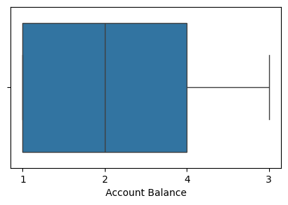

```python
plt.figure(figsize=(5,3))
sns.boxplot(x=df['Account Balance'])
plt.show()
```

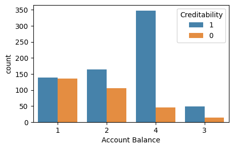

```python
plt.figure(figsize = (5,3))
sns.countplot(x=df['Account Balance'], hue=df['Creditability'], alpha=0.9)
```

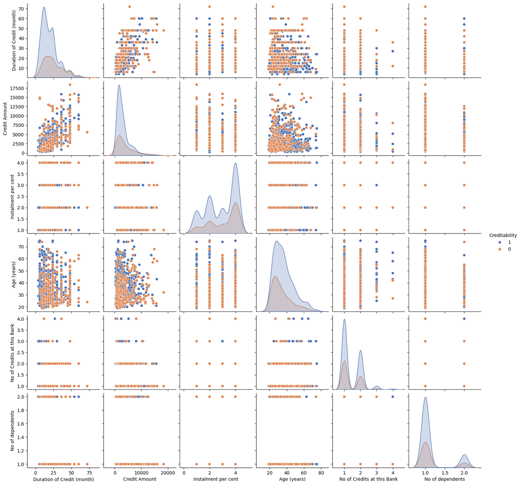

```python
sns.pairplot(df, hue="Creditability", palette="deep")
```

## Normalizing the data

```python
from sklearn.preprocessing import StandardScaler
scaler = StandardScaler()
feature_names= df.columns[df.columns != class_col_name ]
data_x_norm = scaler.fit_transform(df.loc[:, feature_names])
```

```python
x = pd.DataFrame(data=data_x_norm, columns= feature_names)
y=df['Creditability']
x.head()
```

|  | Account Balance | Duration of Credit (month) | Payment Status of Previous Credit | Purpose | Credit Amount | Value Savings/Stocks | Length of current employment | Instalment per cent | Sex & Marital Status | Guarantors | Duration in Current address | Most valuable available asset | Age (years) | Concurrent Credits | Type of apartment | No of Credits at this Bank | Occupation | No of dependents | Telephone | Foreign Worker |
| --- | --- | --- | --- | --- | --- | --- | --- | --- | --- | --- | --- | --- | --- | --- | --- | --- | --- | --- | --- | --- |
| 0 | -1.254566 | -0.240857 | 1.344014 | -0.301852 | -0.787657 | -0.699707 | -1.145978 | 0.918477 | -0.963650 | -0.303686 | 1.046987 | -0.341055 | -1.281573 | 0.460831 | -1.751205 | -0.704926 | 0.146949 | -0.428290 | -0.823318 | -0.196014 |
| 1 | -1.254566 | -0.987573 | 1.344014 | -1.030963 | -0.167384 | -0.699707 | -0.317959 | -0.870183 | 0.449326 | -0.303686 | -0.765977 | -1.293723 | 0.040363 | 0.460831 | -1.751205 | 1.027079 | 0.146949 | 2.334869 | -0.823318 | -0.196014 |
| 2 | -0.459026 | -0.738668 | -0.503428 | 2.250036 | -0.861381 | -0.066488 | 0.510060 | -0.870183 | -0.963650 | -0.303686 | 1.046987 | -1.293723 | -1.105315 | 0.460831 | -1.751205 | -0.704926 | -1.383771 | -0.428290 | -0.823318 | -0.196014 |
| 3 | -1.254566 | -0.738668 | 1.344014 | -1.030963 | -0.407341 | -0.699707 | -0.317959 | 0.024147 | 0.449326 | -0.303686 | -0.765977 | -1.293723 | 0.304750 | 0.460831 | -1.751205 | 1.027079 | -1.383771 | 2.334869 | -0.823318 | 5.101669 |
| 4 | -1.254566 | -0.738668 | 1.344014 | -1.030963 | -0.389974 | -0.699707 | -0.317959 | 0.918477 | 0.449326 | -0.303686 | 1.046987 | -0.341055 | 0.216621 | -2.375050 | 0.135869 | 1.027079 | -1.383771 | -0.428290 | -0.823318 | 5.101669 |

As the Multinomial Naive Bayes classifier (MultinomialNB) from the scikit-learn library requires non-negative feature values, we would ignor this step.

# Modeling with all attributes

# Deviding data for training and testing

```python
from sklearn.model_selection import train_test_split

# Split dataset into training set and test set with Creditability as Our class column
class_col_name='Creditability'
feature_names=df.columns[df.columns != class_col_name ]
x_train, x_test, y_train, y_test = train_test_split(df.loc[:, feature_names], y, test_size=0.3,random_state=1)
```

# Applying Decision Tree algorithm

```python
from sklearn import tree
clf = tree.DecisionTreeClassifier(max_depth=5)
clf = clf.fit(x_train, y_train)
print("Successfuly trained the decision tree...")
```

```
Successfuly trained the decision tree...
```

# Visualizing Desission Tree

```python
import graphviz
#Get unique class values to display on the tree
class_values=df[class_col_name].unique()
print ("class Names",class_values)


dot_data = tree.export_graphviz(clf, out_file=None,
                                feature_names=feature_names,
                                class_names=class_values,
                                filled=True)
# Plot tree
graph = graphviz.Source(dot_data, format="png")
graph
```

```
class Names ['1' '0']
```

[figure not shown]

# Prediction part of Desission Tree Algorithm

```python
y_pred = clf.predict(x_test)
```

```python
from sklearn.metrics import confusion_matrix
cf=confusion_matrix(y_test, y_pred)
print ("Confusion Matrix")
print(cf)
tn, fp, fn, tp=cf.ravel()
print ("TP: ", tp,", FP: ", fp,", TN: ", tn,", FN:", fn)
```

```
Confusion Matrix
[[ 29  62]
 [ 41 168]]
TP:  168 , FP:  62 , TN:  29 , FN: 41
```

```python
from sklearn.metrics import classification_report
from sklearn import metrics

print(classification_report(y_test, y_pred))
```

```
              precision    recall  f1-score   support

           0       0.41      0.32      0.36        91
           1       0.73      0.80      0.77       209

    accuracy                           0.66       300
   macro avg       0.57      0.56      0.56       300
weighted avg       0.63      0.66      0.64       300
```

# Using Dissision Tree Regressor

```python
from sklearn.tree import DecisionTreeRegressor
from sklearn.metrics import mean_squared_error
tree=DecisionTreeRegressor()
tree.fit(x_train,y_train)
```

```
DecisionTreeRegressor()
```

```python
credit_risk_prediction_train=tree.predict(x_train)
credit_risk_prediction_test=tree.predict(x_test)
tree_mse=mean_squared_error(y_test,credit_risk_prediction_test)
tree_rmse=np.sqrt(tree_mse)
tree_rmse
```

```
0.5196152422706632
```

# Applying Naive Bayes algorithm

```python
from sklearn.naive_bayes import MultinomialNB

#Create a MultiNomial NB Classifier
nb = MultinomialNB()

#Train the model using the training sets
nb.fit(x_train, y_train)

#Predict the response for test dataset
y_pred = nb.predict(x_test)
```

```python
print ("Total Columns (including class)",len(df.columns))
```

```
Total Columns (including class) 21
```

```python
print("Number of features used ",nb.n_features_in_)
print("Classes ",nb.classes_)
print("Number of records for classes ",nb.class_count_)
print("Log prior probability for classes ", nb.class_log_prior_)
print("Log conditional probability for each feature given a class\n",nb.feature_log_prob_)
```

```
Number of features used  20
Classes  ['0' '1']
Number of records for classes  [209. 491.]
Log prior probability for classes  [-1.20874608 -0.35463621]
Log conditional probability for each feature given a class
 [[-7.66053824 -5.09289346 -7.52920224 -7.2442712  -0.02385625 -7.77176387
  -7.16792253 -7.18335493 -7.34322437 -8.16470272 -7.27277271 -7.3616411
  -4.77281549 -7.37473764 -7.66053824 -7.98653918 -7.23113472 -8.16470272
  -7.97617639 -8.28352364]
 [-6.96381256 -5.09018055 -7.03265538 -7.02592638 -0.03094527 -7.19521844
  -6.79713562 -6.95892257 -7.02443718 -7.89278845 -6.9965557  -7.21662871
  -4.4432513  -7.02816435 -7.36613136 -7.65976479 -6.96451308 -7.8874834
  -7.68825674 -7.98173594]]
```

```python
from sklearn.metrics import classification_report
from sklearn import metrics

print(classification_report(y_test, y_pred))
```

```
              precision    recall  f1-score   support

           0       0.39      0.41      0.40        91
           1       0.74      0.72      0.73       209

    accuracy                           0.63       300
   macro avg       0.56      0.56      0.56       300
weighted avg       0.63      0.63      0.63       300
```

# Using Gaussion Naive Bayes

```python
from sklearn.naive_bayes import GaussianNB
nb = GaussianNB()
nb.fit(x_train,y_train)
credit_risk_prediction_train = nb.predict(x_train)
credit_risk_prediction_test = nb.predict(x_test)
```

```python
acc_train=accuracy_score(y_train,credit_risk_prediction_train)
acc_test=accuracy_score(y_test,credit_risk_prediction_test)
acc_train,acc_test
```

```
(0.74, 0.7466666666666667)
```

# Modeling with selected attributes

## Data reduction (feature selection baced on correlation matrix)

Based on the correlation between attributes we can omit some attributes that have very low correlation to the class attribut and low effect on our prediction.

```python
df_reduct=df[['Creditability','Account Balance','Duration of Credit (month)','Credit Amount']]
df_reduct
```

|  | Creditability | Account Balance | Duration of Credit (month) | Credit Amount |
| --- | --- | --- | --- | --- |
| 0 | 1 | 1 | 18.0 | 1049.0 |
| 1 | 1 | 1 | 9.0 | 2799.0 |
| 2 | 1 | 2 | 12.0 | 841.0 |
| 3 | 1 | 1 | 12.0 | 2122.0 |
| 4 | 1 | 1 | 12.0 | 2171.0 |
| ... | ... | ... | ... | ... |
| 995 | 0 | 1 | 24.0 | 1987.0 |
| 996 | 0 | 1 | 24.0 | 2303.0 |
| 997 | 0 | 4 | 21.0 | 12680.0 |
| 998 | 0 | 2 | 12.0 | 6468.0 |
| 999 | 0 | 1 | 30.0 | 6350.0 |

1000 rows × 4 columns

```python
from sklearn.model_selection import train_test_split

# Split dataset into training set and test set with Creditability as Our class column
class_col_name='Creditability'
feature_names=df_reduct.columns[df_reduct.columns != class_col_name ]
x_train, x_test, y_train, y_test = train_test_split(df_reduct.loc[:, feature_names], y, test_size=0.3,random_state=1)
```

# Applying Decision Tree algorithm

```python
from sklearn import tree
clf = tree.DecisionTreeClassifier(max_depth=5)
clf = clf.fit(x_train, y_train)
print("Successfuly trained the decision tree...")
```

```
Successfuly trained the decision tree...
```

# Visualizing Desission Tree

```python
import graphviz
#Get unique class values to display on the tree
class_values=df_reduct[class_col_name].unique()
print ("class Names",class_values)


dot_data = tree.export_graphviz(clf, out_file=None,
                                feature_names=feature_names,
                                class_names=class_values,
                                filled=True)
# Plot tree
graph = graphviz.Source(dot_data, format="png")
graph
```

```
class Names ['1' '0']
```

[figure not shown]

# Prediction part of Desission Tree Algorithm

```python
y_pred = clf.predict(x_test)
```

```python
from sklearn.metrics import confusion_matrix
cf=confusion_matrix(y_test, y_pred)
print ("Confusion Matrix")
print(cf)
tn, fp, fn, tp=cf.ravel()
print ("TP: ", tp,", FP: ", fp,", TN: ", tn,", FN:", fn)
```

```
Confusion Matrix
[[ 30  61]
 [ 29 180]]
TP:  180 , FP:  61 , TN:  30 , FN: 29
```

```python
from sklearn.metrics import classification_report
from sklearn import metrics

print(classification_report(y_test, y_pred))
```

```
              precision    recall  f1-score   support

           0       0.51      0.33      0.40        91
           1       0.75      0.86      0.80       209

    accuracy                           0.70       300
   macro avg       0.63      0.60      0.60       300
weighted avg       0.67      0.70      0.68       300
```

```python
from sklearn.tree import DecisionTreeRegressor
from sklearn.metrics import mean_squared_error
tree=DecisionTreeRegressor()
tree.fit(x_train,y_train)
```

```
DecisionTreeRegressor()
```

```python
credit_risk_prediction_train=tree.predict(x_train)
credit_risk_prediction_test=tree.predict(x_test)
tree_mse=mean_squared_error(y_test,credit_risk_prediction_test)
tree_rmse=np.sqrt(tree_mse)
tree_rmse
```

```
0.5916079783099616
```

# Applying Naive Bayes algorithm

```python
from sklearn.naive_bayes import MultinomialNB

#Create a MultiNomial NB Classifier
nb = MultinomialNB()

#Train the model using the training sets
nb.fit(x_train, y_train)

#Predict the response for test dataset
y_pred = nb.predict(x_test)
```

```python
print ("Total Columns (including class)",len(df.columns))
```

```
Total Columns (including class) 21
```

```python
print("Number of features used ",nb.n_features_in_)
print("Classes ",nb.classes_)
print("Number of records for classes ",nb.class_count_)
print("Log prior probability for classes ", nb.class_log_prior_)
print("Log conditional probability for each feature given a class\n",nb.feature_log_prob_)
```

```
Number of features used  3
Classes  ['0' '1']
Number of records for classes  [209. 491.]
Log prior probability for classes  [-1.20874608 -0.35463621]
Log conditional probability for each feature given a class
 [[-7.64343007e+00 -5.07578529e+00 -6.74807861e-03]
 [-6.94016620e+00 -5.06653420e+00 -7.29891260e-03]]
```

```python
from sklearn.metrics import classification_report
from sklearn import metrics

print(classification_report(y_test, y_pred))
```

[output not shown]

# Comparing two results of all attribultes modeling and selected attributes modeling